# act_report

## Report: act_report

- Create a **250-word-minimum written report** called "act_report.pdf" or "act_report.html" that communicates the insights and displays the visualization(s) produced from your wrangled data. This is to be framed as an external document, like a blog post or magazine article, for example.

Apres avoir préparé les données, on s’est posé quelques questions auxquelles on a éssayé de répondre en utilisant les données nettoyées.

A/Quel est le chien le mieux noté ? Etant donné que tous les chiens ont un dénominateur de 10 ( après la correction), le chien le mieux noté est celui avec le numérateur le plus élevé. Pour ceci, on affiche le nom (name) du chien ayant la valeur maximale de numérateur.Atticus est le chien avec le rating le plus élévé.

B/Quelle est la race avec le retweet_count moyen le plus elevé ? En effet, à travers cette question on a cherché à savoir quelle race genére le plus d’interaction entre les utilisateurs de Twitter.On a choisi comme indicateur le nombre moyen de retweet.En effet on a pensé à la moyenne pour avoir un indicateur qui tient compte que les différentes races peuvent ne pas etre representé d’une facon équitable dans la base des données ( la moyenne est pondérée par le nombre d’observation).Pour pouvoir répondre à cette question, on a utilisé la fonction "groupby" et puis la fonction "mean" pour avoir le nombre de retweet moyen par race.Ensuite on a appliqué la fonction sort_values pour avoir les valeurs selon un ordre et voir directement la derniére observation pour voir la race avec le nombre de retweet_count moyen le plus élévé. Pour les races , on a choisi les 1 éres predictions de l’algorithme comme race des chiens."upright" est la race des chiens avec le nombre de retweet moyen le plus élévé(la première prévision semblent etre une mauvaises prédiction du l'algorithme de prevision car il s'agit d'une race de chameau et non pas une race des chiens à ma connaissance).

C/Quelle est la race avec le rating moyen le plus elevé ? En effet, en plus de vouloir savoir quelle race genère le plus des interactions entre les internautes, on voulait également savoir laquelle est la plus «aimée» par ces derniers.On a choisi comme indicateur le score moyen le plus important et donc le numérateur moyen le plus élevé. On a utilisé la 1 ére prédiction comme identifiant de race pour cette question également. Le clumber est la race des chiens avec le rating moyen le plus élévé(Les 3 premières prévisions semblent etre des mauvaises prédiction du l'algorithme de prevision car il s'agit des objets et non pas des races des chiens à ma connaissance)

D/Favorite_count moyen par phase ? Pour cette question on choisi d’opter pour un bar plot de la phase Versus la moyenne de Favorite_count par phase. On conclut que la phase avec le favoite_count moyen le plus elevé est puppo. Ensuite vient le doggo, le floofer et finalement le pupper.

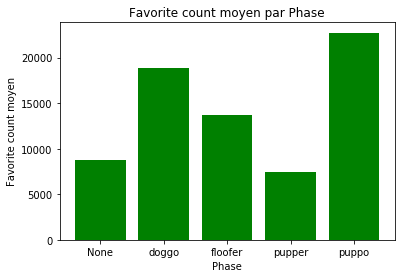